# Reproducible Research: Peer Assessment 1

## Loading and preprocessing the data

> Show any code that is needed to
> 1. Load the data (i.e. `read.csv()`)
> 2. Process/transform the data (if necessary) into a format suitable for your analysis

The data is first unzipped and stored in the *data* directory. The resulting csv file is then read into a data frame using the `read.csv()` function.

```r
# Create a directory to store data, if one doesn't already exist
if(!file.exists("data/")){
    dir.create("data/")
}

# Unzip the data file
unzip(zipfile = "activity.zip", exdir = "data/")

# Load the data and create data frame 'activityDat'
activityDat <- read.csv("data/activity.csv")

# Remove missing values for the first part of the assignment
activityDatNonNA <- activityDat[!is.na(activityDat$steps), ]
```

We can use the `ddply()` function from the `plyr` library to create a new data frame with the number of steps listed by day.

```r
library(plyr)
dailyActivity <- ddply(activityDatNonNA, ~ date, summarize,
                       steps = sum(steps))
```

Finally, to look at the daily activity *pattern* below, we'll use `ddply()` again to create a data frame with the number of steps, averaged across all days, listed by interval.

```r
intervalActivity <- ddply(activityDatNonNA, ~ interval, summarize,
                          averageSteps = mean(steps))
```

## What is mean total number of steps taken per day?

> For this part of the assignment, you can ignore the missing values in the dataset.
> 1. Make a histogram of the total number of steps taken each day
> 2. Calculate and report the **mean** and **median** total number of steps taken per day

The graphing package **ggplot2** can be used to make a histogram of the total number of steps taken each day.

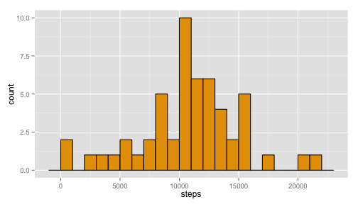

```r
library(ggplot2)
ggplot(dailyActivity, aes(x = steps)) +
    geom_histogram(aes(y = ..count..),
                   binwidth = 1000, colour = "black", fill = "#E69F00")
```

We can then calculate and report the mean and median total number of steps taken per day using the `mean()` and `median()` functions, respectively.

```r
dailyMean <- mean(dailyActivity$steps)
dailyMed <- median(dailyActivity$steps)
```

The mean total number of steps taken per day is **10766.19**.  
The median number of steps per day is **10765**.

## What is the average daily activity pattern?

> 1. Make a time series plot (i.e. `type = "l"`) of the 5-minute interval (x-axis) and the average number of steps taken, averaged across all days (y-axis)
> 2. Which 5-minute interval, on average across all the days in the dataset, contains the maximum number of steps?

We'll use `ggplot()` again to make a line plot (which is equivalent to the `type = "l"` line plot)

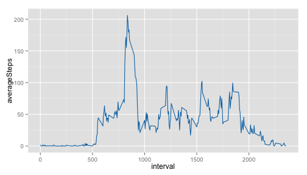

```r
ggplot(intervalActivity, aes(x = interval, y = averageSteps)) +
    geom_line(colour = "#0072B2")
```

The `which.max` function can be used to identify the interval with the maximum number of steps (averaged across all days).

```r
intervalMax <- intervalActivity$interval[
    which.max(intervalActivity$averageSteps)]
```

The interval with the maximum number of steps is **835**.

## Imputing missing values

> Note that there are a number of days/intervals where there are missing values (coded as `NA`). The presence of missing days may introduce bias into some calculations or summaries of the data.
> 1. Calculate and report the total number of missing values in the dataset (i.e. the total number of rows with `NA`s)
> 2. Devise a strategy for filling in all of the missing values in the dataset. The strategy does not need to be sophisticated. For example, you could use the mean/median for that day, or the mean for that 5-minute interval, etc.
> 3. Create a new dataset that is equal to the original dataset but with the missing data filled in.
> 4. Make a histogram of the total number of steps taken each day and Calculate and report the **mean** and **median** total number of steps taken per day. Do these values differ from the estimates from the first part of the assignment? What is the impact of imputing missing data on the estimates of the total daily number of steps?

```r
numNA <- sum(is.na(activityDat$steps))
```

We'll use the mean number of steps for each interval (averaged across all days) to fill in missing values for those intervals. The data frame 'activityDatImputed' represents a new data set with the missing data filled in.

```r
# First identify NA entries corresponding to missing data
naEntries <- row.names(activityDat)[is.na(activityDat$steps)]
activityDatImputed <- activityDat

# For each missing entry, replace the NA with the average number of steps
# across all days for that entry's interval
for(entry in naEntries){
    avgIntervalActivity <- intervalActivity$averageSteps[
        intervalActivity$interval %in% activityDat[entry, "interval"]]
    activityDatImputed[entry, "steps"] <- avgIntervalActivity
}
```

Following the same approach from above, we'll use `ddply()` to create a new data frame with the number of steps listed by day.

```r
dailyActivityImputed <- ddply(activityDatImputed, ~ date, summarize,
                       steps = sum(steps))
```

We can make another histogram with `ggplot()` to look at the distribution of steps taken each day.

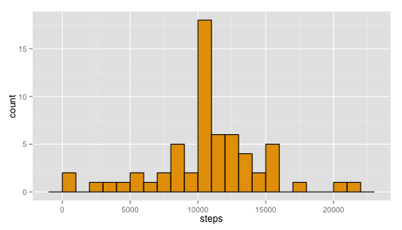

```r
ggplot(dailyActivityImputed, aes(x = steps)) +
    geom_histogram(aes(y = ..count..),
                   binwidth = 1000, colour = "black", fill = "#E69F00")
```

```r
dailyMeanImputed <- mean(dailyActivityImputed$steps)
dailyMedImputed <- median(dailyActivityImputed$steps)
```

## Are there differences in activity patterns between weekdays and weekends?

> For this part the `weekdays()` function may be of some help here. Use the dataset with the filled-in missing values for this part.
> 1. Create a new factor variable in the dataset with two levels – “weekday” and “weekend” indicating whether a given date is a weekday or weekend day.
> 2. Make a panel plot containing a time series plot (i.e. `type = "l"`) of the 5-minute interval (x-axis) and the average number of steps taken, averaged across all weekday days or weekend days (y-axis).

We'll create a new factor variable in the dataset with two levels – “weekday” and “weekend” (indicating whether a given date is a weekday or weekend day) using multiple steps with `weekdays()`, `%in%`, and `as.factor()`.

```r
# Create a logical vector indicating whether each day represents a weekday or
# weekend using the 'weekends' function
weekendDays <- c("Saturday", "Sunday")
isWeekday <- !(weekdays(as.Date(activityDatImputed$date)) %in% weekendDays)

# Create a new variable in 'activityDatImputed' with entries of "weekday" or
# "weekend" corresponding to values of TRUE or FALSE in 'isWeekend',
# respectively
activityDatImputed$day[isWeekday] <- "weekday"
activityDatImputed$day[!isWeekday] <- "weekend"

# Convert the 'day' variable to a two-level factor using 'as.factor'
activityDatImputed$day <- as.factor(activityDatImputed$day)
```

To again look at the daily activity *pattern*, we'll use `ddply()` to create a data frame with the number of steps, averaged across all days, listed by interval; note: this time there will be one entry for the weekday average and one for the weekend average.

```r
intervalActivityImputed <- ddply(activityDatImputed, .(interval, day),
                                 summarize, averageSteps = mean(steps))
```

Finally, to compare activity patterns between weekdays and weekend days, we'll use `ggplot()` to create two line plots, stacked vertically.

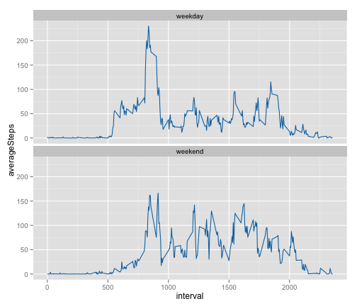

```r
ggplot(intervalActivityImputed, aes(x = interval, y = averageSteps)) +
    geom_line(colour = "#0072B2") +
    facet_wrap(~ day, nrow = 2)
```

Weekend days appear to have more steps per interval on average, but with fewer steps during morning invervals.